# Steam API Tutorial

Denise Cilia  
X81000791  
Social Media Management  
A.A 21/22

# Introduzione

[Steam](https://store.steampowered.com/) è una piattaforma sviluppata da Valve Corporation che si occupa di distribuzione digitale, di gestione dei diritti digitali, di modalità di gioco multigiocatore e di comunicazione. Viene usata per gestire e distribuire una vasta gamma di giochi (alcuni esclusivi) e il loro relativo supporto.

La piattaforma mette a disposizione un'API chiamata Steamworks, che consente agli sviluppatori di usufruire di funzionalità offerte da Steam, tra cui trofei di gioco, microtransazioni e un supporto per i contenuti creati da un utente tramite lo Steam Workshop. Oltre a ciò la piattaforma fornisce anche una piccola selezione di software per la progettazione, anime e film.

# API

L'API è di tipo REST e contiene metodi pubblici a cui è possibile accedere da qualsiasi applicazione in grado di effettuare una richiesta HTTP a `api.steampowered.com`, come client oppure server di gioco.

Le chiamate dell'API hanno la seguente forma `api.steampowered.com`/`interfaceName`/`methodName`/`vVersion`/`?key=apiKey`. Il risultato delle richieste potrà essere uno dei tre seguenti formati: JSON, XML, VDF (Valve Data Format). Se nessun formato viene specificato nella richiesta, l'API darà di default un risultato di tipo JSON.

La lista dei metodi ed interfacce pubblicamente fornite è la seguente:

[ISteamNews](http://developer.valvesoftware.com/wiki/Steam_Web_API#GetNewsForApp_.28v0001.29): Steam offre metodi per ottenere news e aggiornamenti per ciascun gioco sulla piattaforma Steam.

ISteamUserStats: Steam offre metodi per ottenere le statistiche globali ed informazioni di un gioco in particolare.

[ISteamUser](http://developer.valvesoftware.com/wiki/Steam_Web_API#GetPlayerSummaries_.28v0001.29): Steam offre delle chiamate API per ottenere informazioni generiche e specifiche degli utenti Steam.

In generale troviamo la documentazione completa e ufficiale fornita da Steam a questo link: [Docs](https://partner.steamgames.com/doc/webapi)

# Accesso all'API

Per poter utilizzare le API dobbiamo innanzitutto avere un profilo utente Steam. Qualora non si possedesse un profilo utente è possibile crearlo in modo rapido e intuitivo cliccando [qui](https://store.steampowered.com/join).

Effettuiamo dunque l'[accesso](https://steamcommunity.com/login/home/?goto=%2Fdev%2Fapikey) a Steam per ottenere le chiavi per poter utilizzare l'API.

La schermata che visualizziamo è la seguente:

[figure not shown]

Una volta inserite le nostre credenziali avremo la possibilità di ottenere una chiave inserendo un nome di dominio (può essere qualsiasi è una scelta puramente formale).

[figure not shown]

È bene notare che Valve segue una politica molto ristretta per quanto riguarda l'autenticazione tramite OAuth (vedi sezione [Introduzione](https://partner.steamgames.com/doc/webapi_overview/oauth)). Per poter ottenere il `clientId` utile all'implementazione della richiesta di autorizzazione bisogna contattare Valve e fornire le informazioni richieste.

Questo studio è fortemente concentrato su una serie di dati ad accesso **pubblico**. È dunque fondamentale che il profilo preso in studio abbia una privacy settata su **pubblico**. Ottenuta la nostra chiave pubblica possiamo adesso mostrare una sezione di codice utile ad ottenere diversi dati utili ai fini di uno studio di profilazione.

Inseriamo in questa variabile la nostra chiave da sviluppatore:

```python
apiKey = 'YOUR_API_KEY'
```

# Steam API Wrapper

Prima di procedere alla spiegazione sull'uso dell'API Steam mostriamo un Wrapper di Steam scritto in Python che permette di nascondere le richieste HTTP. Si tratta di una libreria che rende semplice l'accesso ad alcune informazioni dell'utente; possiamo accedere velocemente alla lista di amici dell'utente, alla lista di giochi generica e alla lista dei titoli giocati recentemente e altre funzionalità.

Vediamo qualche piccolo esempio:

```python
import steamapi

steamapi.core.APIConnection(api_key=apiKey, validate_key=True)

steam_user = steamapi.user.SteamUser(userurl = "YOUR_NICKNAME")

steam_user.friends
```

```
[<SteamUser "Mip" (76561198044574276)>,
 <SteamUser "Louphelle" (76561198051550543)>,
 <SteamUser "Jack King Goff" (76561198057136350)>,
 <SteamUser "TakaEyes" (76561198072068013)>,
 <SteamUser "Salvo4682" (76561198089183727)>,
 <SteamUser "Pancake alla Carciofina" (76561198104736604)>,
 <SteamUser "MarkTenma" (76561198106411612)>,
 <SteamUser "Swaccney" (76561198119254643)>,
 <SteamUser "Kepler" (76561198127997667)>,
 <SteamUser "CWS_97" (76561198142803553)>,
 <SteamUser "Riky68" (76561198155403000)>,
 <SteamUser "Kuroshiroix" (76561198188057123)>,
 <SteamUser "V" (76561198241697476)>,
 <SteamUser "CristaDoloris" (76561198269433080)>,
 <SteamUser "isidorodibartolo97" (76561198274365212)>,
 <SteamUser "ninni.cicci96" (76561198312852812)>,
 <SteamUser "mononoke2" (76561198346442638)>,
 <SteamUser "LaPHToxiNe.gamehag.com" (76561198349223210)>,
 <SteamUser "Niser" (76561198377913347)>,
 <SteamUser "gabry05" (76561198410768083)>,
 <SteamUser "R3DFox21" (76561198430290738)>,
 <SteamUser "Arisaka117" (76561198442382861)>,
 <SteamUser "Lince" (76561198821148601)>,
 <SteamUser "trepuntini" (76561198821700520)>,
 <SteamUser "antho99" (76561198839493532)>,
 <SteamUser "14giovy" (76561198844700805)>,
 <SteamUser "Davidpool" (76561198867378314)>,
 <SteamUser "centaurus97" (76561199006490525)>,
 <SteamUser "Schillinger19" (76561199207632683)>]
```

Tra parentesi troviamo indicato l'**id64** univoco per ciascun utente.

```python
steam_user.recently_played
```

```
[<SteamApp "Resident Evil 7 Biohazard" (418370)>,
 <SteamApp "Don't Starve Together" (322330)>,
 <SteamApp "Thronebreaker: The Witcher Tales" (973760)>,
 <SteamApp "BLEACH Brave Souls - 3D Action" (1201240)>,
 <SteamApp "Resident Evil 2" (883710)>,
 <SteamApp "Yu-Gi-Oh!  Master Duel" (1449850)>,
 <SteamApp "Dead Island Definitive Edition" (383150)>,
 <SteamApp "Orcs Must Die! 2" (201790)>,
 <SteamApp "Goat Simulator" (265930)>,
 <SteamApp "Undertale" (391540)>,
 <SteamApp "The Binding of Isaac: Rebirth" (250900)>,
 <SteamApp "Skul: The Hero Slayer" (1147560)>,
 <SteamApp "Five Nights at Freddy's" (319510)>,
 <SteamApp "Borderlands GOTY Enhanced" (729040)>,
 <SteamApp "The Binding of Isaac" (113200)>,
 <SteamApp "Home Sweet Home" (617160)>,
 <SteamApp "Wallpaper Engine" (431960)>]
```

Allo stesso modo, troviamo tra parentesi l'**id** univoco di ciascun gioco.

Purtroppo la libreria non è ben documentata, disponiamo di una piccolissima [wiki](https://github.com/smiley/steamapi/wiki/User) incentrata principalmente sui metodi che riguardano l'utente. \ Per questo studio si decide dunque di procedere utilizzando in via diretta l'API ufficiale fornita da Steam.

# Utilizzo dell'API

Definiamo una funzione `sendRequest`.

Ritorna una risposta in formato json di una generica richiesta GET utilizzando parametri da definire. Quest'ultimi saranno `url` che è una stringa e `parameters` che rappresenta un dizionario utilizzato per memorizzare i valori in coppie del tipo key:valore. In questo caso `parameters` sarà utilizzata per impostare i vari parametri per personalizzare la chiamata API su un determinato url.

```python
import requests

def sendRequest(url, parameters = None):
    requests.adapters.DEFAULT_RETRIES = 5
    result = requests.get(url = url, params = parameters, timeout = 5)

    return result.json()
```

Utilizziamo dunque `sendRequest` per poter ottenere l'`id64` dell'utente Steam. Con questo risultato saremo in grado di risolvere diverse query che riguardano l'utente in particolare.

```python
parameters = {'key':apiKey, 'vanityurl':'YOUR_NICKNAME'}
url = "http://api.steampowered.com/ISteamUser/ResolveVanityURL/v0001/"

result = sendRequest(url, parameters)
personalUID = result['response']['steamid']

personalUID
```

```
'76561198093585873'
```

Definiamo adesso una funzione `userSummaries` in grado di dare in output i dati personali dell'utente, quali:

- nome
- nickname
- ultimo accesso
- città e paese di provenienza

```python
from datetime import datetime

def userSummaries():
        url = "https://api.steampowered.com/ISteamUser/GetPlayerSummaries/v0002/"
        params = {'key':apiKey, 'steamids':personalUID}
        result = sendRequest(url, params)
        result = result['response']['players']
        realName = result[0]['realname']
        nickname = result[0]['personaname']
        lastSeen = datetime.fromtimestamp(result[0]['lastlogoff'])
        country = str(result[0]['loccountrycode'])
        stateCode = str(result[0]['locstatecode'])
        url = "https://steamcommunity.com/actions/QueryLocations/" + country + "/" + stateCode
        params = None

        location = sendRequest(url, params)
        for i in range(len(location)):
            if location[i]['cityid'] == result[0]['loccityid']:
                city = location[i]['cityname']

        print("Il nome dell'utente è " + realName + ", il suo nickname è " + nickname + ", il suo ultimo accesso è stato effettuato in data " + str(lastSeen) + ", la sua città è " + city + ", " + country)
```

### IPlayerService/GetOwnedGames

```python
import pandas as pd
import math

def getAllGames():
    parameters = {'key':apiKey, 'include_appinfo':'TRUE', 'steamid':personalUID, 'format':'json'}
    url = "https://api.steampowered.com/IPlayerService/GetOwnedGames/v0001/"
    list_of_games = sendRequest(url, parameters)
    list_of_games = list_of_games['response']['games']

    dictList = []
    recently_played = []

    for i in range(len(list_of_games)):
        try:
            list_of_games[i]['playtime_2weeks']
        except:
            recently_played.append("no")
        else:
            recently_played.append("yes")
        games = {
            'id':list_of_games[i]['appid'],
            'name':list_of_games[i]['name'],
            'hours_of_game':math.ceil((list_of_games[i]['playtime_forever']/60)),
            'recently_played':recently_played[i]
        }
        dictList.append(games)

    df = pd.DataFrame(dictList)
    return df

data = getAllGames()
data
```

|  | id | name | hours_of_game | recently_played |
| --- | --- | --- | --- | --- |
| 0 | 20 | Team Fortress Classic | 0 | no |
| 1 | 15710 | Oddworld: Abe's Exoddus | 0 | no |
| 2 | 9480 | Saints Row 2 | 0 | no |
| 3 | 1250 | Killing Floor | 1 | no |
| 4 | 35420 | Killing Floor Mod: Defence Alliance 2 | 0 | no |
| ... | ... | ... | ... | ... |
| 291 | 46510 | Syberia 2 | 0 | no |
| 292 | 204450 | Call of Juarez Gunslinger | 0 | no |
| 293 | 520720 | Dear Esther: Landmark Edition | 0 | no |
| 294 | 1577120 | The Quarry | 0 | no |
| 295 | 1515950 | Capcom Arcade Stadium | 0 | no |

296 rows × 4 columns

Definiamo una funzione `getAllGames` che ci permette di avere in output la lista di tutti i giochi in possesso, inserita all'interno di un dataframe. Le colonne sono id, name, hours_of_game e recently_played e descrivono rispettivamente:

- id univoco e identificativo per il gioco
- nome del gioco
- ore di gioco dell'utente
- se è stato giocato nelle ultime due settimane

[Docs](https://developer.valvesoftware.com/wiki/Steam_Web_API#GetOwnedGames_.28v0001.29)

### AppDetails

```python
from time import sleep

def getGenres():
    url = "https://store.steampowered.com/api/appdetails/"

    genre = []
    for i in range(len(data)):
        endstring = ''
        parameters = {'appids':data['id'][i]}
        result = sendRequest(url, parameters)
        tmp = data['id'][i]
        temp = f'{tmp}'
        try:
            result[temp]['data']['genres'][0]['description']
        except:
            genre.append('NA') # se non vi è alcuna specifica sul genere indichiamo un NOT AVAILABLE
        else:
            for gen in range(len(result[temp]['data']['genres'])):
                endstring += result[temp]['data']['genres'][gen]['description']
                endstring += " " # potrebbe esserci più di un genere per gioco quindi utilizziamo una stringa finale per poter concatenare tutti i generi
            genre.append(endstring)
        sleep(1) # utilizziamo una sleep per non inondare di richieste il server ed evitare che chiuda la connessione HTTP

    return genre

test = getGenres()
test
```

```
['Action ',
 'Adventure ',
 'Action ',
 'Action ',
 'Action ',
 'Action Adventure ',
 'RPG ',
 'Action Adventure ',
 'Action Adventure ',
 'Action ',
 'NA',
 'Action ',
 'Adventure Casual Indie ',
 'Action Adventure Indie RPG ',
 'RPG ',
 'Action RPG ',
 'Action RPG ',
 'Action Adventure Indie RPG ',
 'Action ',
 'Action ',
 'Indie Strategy ',
 'Action ',
 'Action Adventure Indie RPG Strategy ',
 'Action Adventure Indie Simulation ',
 'Action RPG ',
 'Action ',
 'Action Adventure ',
 'Simulation Strategy ',
 'Adventure ',
 'Action Free to Play Massively Multiplayer ',
 'Action Free to Play Indie Massively Multiplayer RPG ',
 'Action Adventure Free to Play Massively Multiplayer RPG ',
 'Action Free to Play Massively Multiplayer ',
 'Action Free to Play Massively Multiplayer ',
 'Action Adventure Free to Play Indie Massively Multiplayer RPG ',
 'Action Adventure ',
 'Action Adventure Strategy ',
 'Action ',
 'NA',
 'Racing Sports ',
```

[output cut: 241 more lines]

```
 'Action ',
 'Strategy ',
 'Action Adventure Free to Play Indie Massively Multiplayer Simulation Strategy ',
 'Adventure ',
 'Casual Simulation ',
 'Action Adventure Indie ',
 'Action Adventure Casual Indie Simulation Strategy ',
 'Action Adventure Free to Play Massively Multiplayer ',
 'Strategy ',
 'Adventure Casual ',
 'Adventure ',
 'Action ',
 'Adventure Casual Indie ',
 'Adventure ',
 'Action Free to Play ']
```

```python
data['genres'] = test

def mostPlayed():
    result = data.loc[(data['recently_played'] == "yes") & (data['hours_of_game'] >= 50)]
    return result

most_played = mostPlayed()
most_played
```

|  | id | name | hours_of_game | recently_played | genres |
| --- | --- | --- | --- | --- | --- |
| 17 | 113200 | The Binding of Isaac | 99 | yes | Action Adventure Indie RPG |
| 97 | 250900 | The Binding of Isaac: Rebirth | 392 | yes | Action |
| 110 | 322330 | Don't Starve Together | 942 | yes | Adventure Indie Simulation |
| 219 | 883710 | Resident Evil 2 | 62 | yes | Action |
| 230 | 1147560 | Skul: The Hero Slayer | 50 | yes | Action Indie |
| 235 | 1201240 | BLEACH Brave Souls - 3D Action | 634 | yes | Action Casual Free to Play RPG |
| 269 | 1449850 | Yu-Gi-Oh! Master Duel | 113 | yes | Free to Play Simulation Strategy |

Estraiamo con la funzione `mostPlayed` i titoli giocati nelle ultime due settimane e le cui ore di gioco totali sono maggiori o uguali a 50. Otterremo così una lista di giochi dalla quale sarà possibile estrarre gli achievements del giocatore.

### ISteamUserStats/GetGlobalAchievementPercentagesForApp

```python
def globalPercentageOfAchievement(n):
    globalPercentage = []
    url = 'https://api.steampowered.com/ISteamUserStats/GetGlobalAchievementPercentagesForApp/v0002/'
    params = {'gameid':most_played.iloc[n]['id'], 'format':'json'}
    result = sendRequest(url, params)
    result = result['achievementpercentages']['achievements']
    for i in range(len(result)):
        globalPercentage.append(result[i]['percent'])

    return globalPercentage
```

[Docs](https://developer.valvesoftware.com/wiki/Steam_Web_API#GetGlobalAchievementPercentagesForApp_.28v0002.29).

### ISteamUserStats/GetPlayerAchievements

```python
from datetime import datetime

def getAchievements(n):
    url = 'http://api.steampowered.com/ISteamUserStats/GetPlayerAchievements/v0001/'
    params = {'appid':most_played.iloc[n]['id'], 'key':apiKey, 'steamid':personalUID}
    result = sendRequest(url, params)
    result = result['playerstats']['achievements']
    percentage = globalPercentageOfAchievement(n)
    dictList = []
    for i in range(len(result)):
        for j in range(len(result[i])):
            tmp = {
                'name':result[i]['apiname'],
                'achieved':result[i]['achieved'],
                'timestamp':datetime.fromtimestamp(result[i]['unlocktime']),
                'global_percentage_of_unlock':math.ceil(percentage[i])/100
            }
        dictList.append(tmp)
    result = pd.DataFrame(dictList)

    return result
```

[Docs](https://developer.valvesoftware.com/wiki/Steam_Web_API#GetPlayerAchievements_.28v0001.29).

Supponendo di conoscere la posizione di un titolo all'interno della libreria di giochi, indichiamo con *N* tale posizione e la utilizziamo come parametro nelle funzioni `globalPercentageOfAchievement` e `getAchievements`.

- **globalPercentageOfAchievement** ci permette di ottenere una panoramica globale sugli achievements di un gioco specifico in percentuali. In altre parole è la percentuale generale di sblocco dei trofei studiata sulla base delle statistiche di sblocco di tutti i giocatori nel mondo per quel particolare gioco.
- **getAchievements** ritorna la lista di achievements dell'utente, ottenuti e non, utilizzando l'id univoco ed identificativo del gioco in particolare.

Uniamo il risultato della prima e della seconda funzione in un unico dataframe che presenta le seguenti colonne: **name** (nome dell'achievement), **achieved** (valore booleano che indica se l'achievement *i* è stato sbloccato), **timestamp** (indica la data e l'ora in cui è stato sbloccato l'achievement) e **global_percentage_of_unlock** (mostra la percentuale generale di sblocco per l'achievement *i*

Vediamo degli esempi:

```python
n = 3 # Resident Evil 2
achievements = []
gameName = []
gameName.append(most_played.iloc[n]['name'])
achievements.append(getAchievements(n))
achievements[0].head()
```

|  | name | achieved | timestamp | global_percentage_of_unlock |
| --- | --- | --- | --- | --- |
| 0 | NEW_ACHIEVEMENT_1_1 | 1 | 2020-11-27 19:37:13 | 0.95 |
| 1 | NEW_ACHIEVEMENT_1_2 | 1 | 2021-12-08 15:59:37 | 0.87 |
| 2 | NEW_ACHIEVEMENT_1_3 | 1 | 2021-12-08 17:15:48 | 0.85 |
| 3 | NEW_ACHIEVEMENT_1_4 | 1 | 2021-12-08 17:35:48 | 0.83 |
| 4 | NEW_ACHIEVEMENT_1_5 | 1 | 2021-12-09 15:41:55 | 0.83 |

```python
n = 0 # The Binding of Isaac
gameName.append(most_played.iloc[n]['name'])
achievements.append(getAchievements(n))
achievements[1]
```

|  | name | achieved | timestamp | global_percentage_of_unlock |
| --- | --- | --- | --- | --- |
| 0 | The_Noose | 1 | 2021-01-31 16:01:44 | 0.71 |
| 1 | The_Nail | 1 | 2021-02-01 13:59:11 | 0.63 |
| 2 | The_Quarter | 1 | 2021-02-01 21:30:55 | 0.60 |
| 3 | The_Fetus | 1 | 2021-02-02 18:45:06 | 0.57 |
| 4 | Terrible | 1 | 2021-02-03 13:01:47 | 0.49 |
| ... | ... | ... | ... | ... |
| 94 | psam | 1 | 2021-08-27 00:55:45 | 0.02 |
| 95 | peve | 1 | 2021-08-23 12:50:03 | 0.02 |
| 96 | pblue | 1 | 2021-08-23 20:32:58 | 0.02 |
| 97 | ppers | 1 | 2021-08-27 00:55:45 | 0.02 |
| 98 | egod | 0 | 1970-01-01 01:00:00 | 0.02 |

99 rows × 4 columns

```python
n = 6 # Yu-Gi-Oh! Master Duel
gameName.append(most_played.iloc[n]['name'])
achievements.append(getAchievements(n))
achievements[2]
```

|  | name | achieved | timestamp | global_percentage_of_unlock |
| --- | --- | --- | --- | --- |
| 0 | jp.konami.masterduel.ach.001 | 1 | 2022-01-19 15:36:42 | 0.89 |
| 1 | jp.konami.masterduel.ach.002 | 1 | 2022-07-18 00:40:48 | 0.43 |
| 2 | jp.konami.masterduel.ach.003 | 1 | 2022-02-18 14:20:50 | 0.40 |
| 3 | jp.konami.masterduel.ach.004 | 1 | 2022-03-18 23:52:43 | 0.37 |
| 4 | jp.konami.masterduel.ach.005 | 1 | 2022-03-14 20:22:11 | 0.33 |
| 5 | jp.konami.masterduel.ach.006 | 1 | 2022-03-07 00:29:47 | 0.25 |
| 6 | jp.konami.masterduel.ach.007 | 1 | 2022-02-18 19:09:52 | 0.21 |
| 7 | jp.konami.masterduel.ach.008 | 1 | 2022-03-14 00:56:00 | 0.20 |
| 8 | jp.konami.masterduel.ach.009 | 1 | 2022-03-13 15:13:22 | 0.17 |
| 9 | jp.konami.masterduel.ach.010 | 1 | 2022-02-19 19:45:09 | 0.07 |
| 10 | jp.konami.masterduel.ach.011 | 1 | 2022-03-14 22:58:30 | 0.07 |

Dai dati ottenuti definiamo una funzione `platinum` che darà in output True se il gioco è stato platinato. Un gioco si definisce **platinato** se tutti gli achievements sono stati sbloccati dal giocatore.

```python
from statistics import mean

def platinum(x):
    count = 0
    for i in range(len(x)):
        if x.iloc[i]['achieved'] == 1:
            count += 1
    if count == len(x):
        return True

for i in range(len(achievements)):
    meanAch = mean((achievements[i]['global_percentage_of_unlock'])) * 100
    meanAch = str("{:.2f}".format(meanAch)) + '%'
    if platinum(achievements[i]):
        print("Il giocatore ha sbloccato tutti gli achievements di " + gameName[i] + ". La media di rarita' dei vari trofei e' " + meanAch)
    else:
        print("Il giocatore non ha sbloccato tutti gli achievements di " + gameName[i] + ". La media di rarita' dei vari trofei e' " + meanAch)
```

```
Il giocatore ha sbloccato tutti gli achievements di Resident Evil 2. La media di rarita' dei vari trofei e' 41.55%
Il giocatore non ha sbloccato tutti gli achievements di The Binding of Isaac. La media di rarita' dei vari trofei e' 16.35%
Il giocatore ha sbloccato tutti gli achievements di Yu-Gi-Oh!  Master Duel. La media di rarita' dei vari trofei e' 30.82%
```

Calcolare la media di rarità dei vari achievements, cioè la media delle percentuali globali, ci può aiutare nell'individuare la difficoltà di uno specifico gioco. Possiamo dunque affermare che giochi con una media percentuale di sblocco bassa hanno una difficoltà medio/alta, viceversa giochi con una media percentuale di sblocco alta hanno una difficoltà bassa.

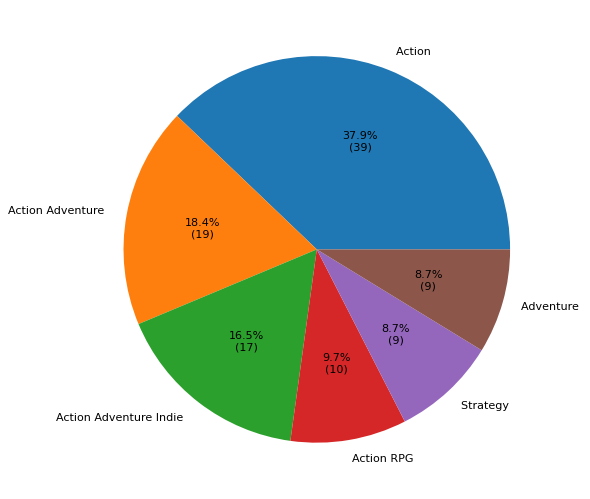

```python
import matplotlib.pyplot as plt
from matplotlib.pyplot import figure

def autopct_format(values):
    def my_format(pct):
        total = sum(values)
        val = int(round(pct*total/100.0))
        return '{:.1f}%\n({v:d})'.format(pct, v=val)
    return my_format

filtered_data = data[data['genres'] != "NA"] # rimuoviamo i giochi il cui genere non è indicato

figure(figsize = (8, 8), dpi = 80)
genres_dict= filtered_data['genres'].value_counts().to_dict()
genres_list = list(genres_dict.keys())
genres_quantity = list(genres_dict.values())

plt.pie(genres_quantity[:6], labels = genres_list[:6], autopct = autopct_format(genres_quantity[:6]))
plt.show()
```

Considerando i giochi frequentemente giocati dall'utente calcoliamo una stima che descrive quante ore gioca in media l'utente:

```python
def avgHoursOfGame():
    result = data.loc[(data['recently_played'] == "yes") & (data['hours_of_game'] <= 400)] # rimuovo l'errore
    result = math.ceil(mean(result['hours_of_game']))
    return str(result)

print("Considerando che 'recently_played' ha al suo interno record che riguardano le ultime due settimane di gioco, calcoliamo che l'utente gioca in media " + avgHoursOfGame() + " ore in due settimane. Dunque 57/14, l'utente gioca circa 4 ore al giorno.")
```

[output not shown]

# Conclusione

Il nostro studio ha dato come risultato una classifica di generi per l'utente:

1. Al primo posto troviamo i titoli di **Azione**
2. Al secondo posto troviamo i titoli di **Azione** e **Avventura**
3. Al terzo posto troviamo i titoli di **Azione**, **Avventura** e **Indie**.

Questo risulta dunque un caso di studio base possibile attraverso l'utilizzo dei metodi pubblici forniti da Steam e applicabile solo esclusivamente a profili **pubblici**. È possibile ampliare lo studio anche su profili **privati** grazie al rilascio del `clientId` da parte di Valve con un'apposita richiesta formale inviata all'azienda stessa. L'uso generale dell'API rimane comunque abbastanza semplice e non vi è strettamente bisogno di un wrapper per poter semplificare le operazioni.

Fonti:

1. https://it.wikipedia.org/wiki/Steam_(informatica)
2. https://steamcommunity.com/dev?l=italian